# Bayesian Robust Multivariate Linear Regression with Incomplete Response

Haoxiang Li

10/6/2022

This vignette is an introduction of Bayesian robust multivariate linear regression (with possible incomplete data), and the data augmentation algorithms to sample from the posterior. See our [paper](http://arxiv.org/abs/2212.01712) for technical details.

```r
set.seed(1)
library(Bayesianrobust) # load our package
```

# Introduction

## Model

Consider the multivariate linear regression model
$$\mathbf{Y}_i = \mathbf{B}^T \mathbf{x}_i + \mathbf{\Sigma}^{1/2}
\mathbf{\varepsilon}_i,\ i \in \{1,\dots,n\},$$
where $\mathbf{B}$ is a $p\times d$ matrix of unknown regression coefficients, $\mathbf{\Sigma}$ is a $d\times d$ unknown positive definite scatter matrix, and $\mathbf{\varepsilon}_i, \; i\in\{1,\dots,n\}$, are $d\times1$ iid random errors.

To model possible influential observations in normal errors, we use error distributions with heavy tails. Assume that the distribution of each $\mathbf{\varepsilon}_i$ is described by a scale mixture of multivariate normal densities, which takes the form
$$f_{\text{err}}(\mathbf{\epsilon}) = \int_{0}^{\infty}
\frac{w^{d/2}}{(2\pi)^{d/2}} \exp \left(-\frac{w}{2}
\mathbf{\epsilon}^{T} \mathbf{\epsilon} \right) P_{mix}( w) , \quad
\mathbf{\epsilon} \in \mathbb{R}^d,$$
where $P_{mix}(\cdot)$ is a probability measure function on $\mathbb{R}^+$ referred to as the mixing distribution. Gaussian mixtures constitute a variety of error distributions and are widely used for robust regression. For instance, when $P_{mix}(\cdot)$ corresponds to the $\text{Gamma}(v/2,v/2)$ distribution for some $v > 0$, the errors follow the multivariate $t$ distribution with $v$ degrees of freedom.

Consider a Bayesian setting. Assume that $(\mathbf{B},\mathbf{\Sigma})$ has the following prior density:
$$p_{\scriptsize\mbox{prior}}(\mathbf{\beta},
\mathbf{\varsigma}) \propto |\mathbf{\varsigma}|^{-(m+1)/2} \exp
\left[-\frac{1}{2} \operatorname{tr} \left(\mathbf{\varsigma}^{-1}
\mathbf{a} \right)\right], \quad \mathbf{\beta} \in \mathbb{R}^{p \times
d}, \; \mathbf{\varsigma} \in S_+^{d \times d},$$
where $m\in \mathbb{R}$, $\mathbf{a} \in S_+^{d \times d}$, and $S_+^{d \times d}$ is the convex cone of $d \times d$ (symmetric) positive semi-definite real matrices. For instance, the independence Jeffrey’s prior corresponds to $m=d$ and $\mathbf{a}=0$, and the non-informative constant prior corresponds to $m=-1$ and $\mathbf{a}=0$.

## Incomplete Data

we assume that the missing data mechanism is ignorable, which is true if the missing structure does not depend on model parameters and is independent of the data values.

A missing structure is said to be monotone if it can be sorted into the following standard format below after permuting the rows and columns. The data without missing values is monotone.

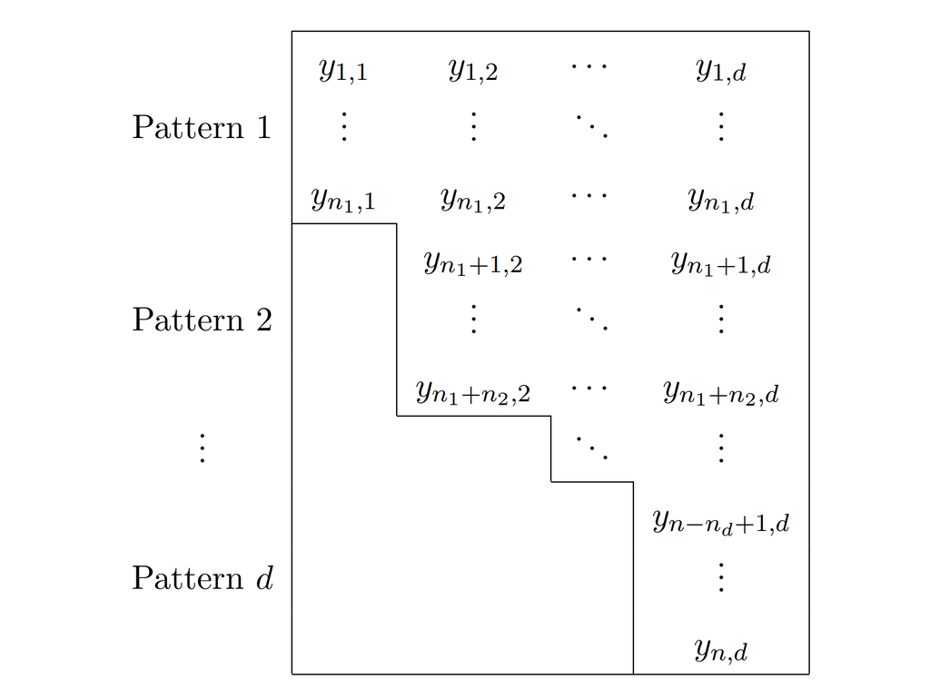

The standard monotone format.

The function helps check whether the data is monotone or not and permutes the rows and columns of the data to the standard monotone format.

```r
# 1 not monotone
a <- c(NA, 1, 4, NA, 5, 9)
b <- c(2, NA, 3, 5, 6, NA)
c <- c(2, 4, 6, NA, 5, 6)
x <- c(1, 2, 3, 4, 5, 6)
yobs <- data.frame(a, b, c)
ismonotone(yobs, x)
```

```
#> $monotone
#> [1] FALSE
#>
#> $ynew
#>       a  b  c
#> [1,]  4  3  6
#> [2,]  5  6  5
#> [3,] NA  2  2
#> [4,]  1 NA  4
#> [5,]  9 NA  6
#> [6,] NA  5 NA
#>
#> $ynew_column
#> [1] 1 2 3
#>
#> $ynew_row
#> [1] 3 5 1 2 6 4
#>
#> $xnew
#>      [,1]
#> [1,]    3
#> [2,]    5
#> [3,]    1
#> [4,]    2
#> [5,]    6
#> [6,]    4
#>
#> $permute
#> [1] TRUE
```

In this example, the missing structure of the data is not monotone. We recommend to permute the rows and columns of the data.

## The Data Augmentation Algorithms

The posterior is almost always intractable in the sense that it is hard to calculate its features such as expectation and quantiles, forcing the use of MCMC. [Liu, 1996](https://www.jstor.org/stable/2291740) proposed a data augmentation (DA) algorithm, or two-component Gibbs sampler, that can be used to sample from this distribution under monotone missing patterns. The algorithms contain two steps, the I step and the P step.

When the missing data have a certain ``monotone” structure, the DA algorithm can be carried out without an intermediate step to impute the missing data.

When the missing data do not possess a monotone structure, some missing entries need to be imputed if one wishes to implement the DA algorithm. We call this data augmentation algorithm with an intermediate imputation step (DAI). Let $\textbf{k}$ be the missing structure of $\textbf{y}$. Users can specify a larger missing structure $\textbf{k}'$, which represents the missing structure after mandatory imputation. $\textbf{k}'$ is larger than $\textbf{k}$ if all elements observed under $\textbf{k}$ are also observed under $\textbf{k}'$.

In the R functions. the missing structure $\textbf{k}'$ corresponds to $Ik$, and $\textbf{k}$ corresponds to $I$. The default $Ik$ represents fully observed. Users can use function to implement these algorithms. It will automatically find the best fit to sample from the posterior.

To make sure the algorithm can be implemented efficiently, we need two weak conditions. The conditions are true in most situations. See the [paper](http://arxiv.org/abs/2212.01712) Conditions H1 and H2, and Proposition 3. We also develop conditions to guarantee proper posteriors and geometric ergodicity. See the [paper](http://arxiv.org/abs/2212.01712) Theorem 7.

# R Implementation

## Illustrative Example

The creatinine clearance data is introduced by Shih and Weisberg (1986), and is used in an illustrative example by Liu (1996).

The data are from a clinical trial on 34 male patients with body weight (WT) in kg, serum creatinine (SC) concentration in mg/deciliter, age (AGE) in years, and endogenous creatinine (CR) clearance. InSC = In(SC), InWT = In(WT), InCR = In(CR), In140_AGE = In(140-AGE). Of the 34 male patients, 2 had no record in WT and 4 were missing SC. The missingness is assumed to be ignorable. There is one influential observation patient 27. We use (InSC, InWT, InCR) as responses and (1, In140_AGE) as predictors (with intercept).

### Missing structure

Check whether the response is monotone or not after permuting the rows and columns.

```r
# get data
x <- cbind(1, creatinine_data["In140_AGE"]) # include intercept features
y <- creatinine_data[c("InSC", "InWT", "InCR")] # responses
mon <- ismonotone(y, x)
```

The response is not monotone.

```r
mon$monotone
```

```
#> [1] FALSE
```

Permute the rows and columns are not necessary.

```r
mon$permute
```

```
#> [1] FALSE
```

```r
yobs <- mon$ynew
xobs <- mon$xnew
```

When the missing structure is monotone. Use the rearranged data for later analysis, since the data is required to be in the standard monotone format.

When the missing structure is not monotone. It is suggested to use the rearranged data. The results are the same, and the permuted version displays the missing structure better.

Shows the locations of the rows and columns in the original data.

```r
mon$ynew_column
```

```
#> [1] 1 2 3
```

```r
mon$ynew_row
```

```
#>  [1]  1  2  3  4  5  6  7  8  9 10 11 12 13 14 15 16 17 18 19 20 21 22 23 24 25
#> [26] 26 27 28 29 30 31 32 33 34
```

### Implement the data augmentation algorithms

Suppose we want the independence Jeffrey’s prior with mixing distribution Gamma(2,2).

```r
iter <- 5000
mcmc <- dageneral(xobs, yobs, m=ncol(yobs), A=diag(0,ncol(yobs)), cw=cw_gamma, iter=iter)
```

```
#> [1] "daif"
```

The algorithm generates a Markov chain with length 5000. And the computation time is 49.07.

### Assess the MCMC samples

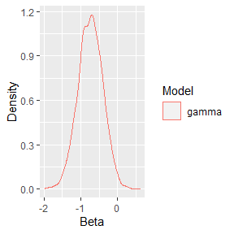

```r
library(ggplot2)
lower <- 10 # burn-in
upper <- iter + 1
dim <- 2 # beta(2,1)
sim <- data.frame(Model=rep(c("gamma"), each=(upper - lower + 1)), beta= mcmc$samples[lower:upper, dim])
ggplot(sim, aes(x=beta, color=Model)) + geom_density() + xlab("Beta") + ylab("Density")
```

We try more mixing distribution choices.

Constant. This corresponds to the normal error.

```r
# constant
mcmc_c <- dageneral(xobs, yobs, m=ncol(yobs),A=diag(0,ncol(yobs)), cw=cw_constant, iter=iter)
```

```
#> [1] "daif"
```

### Mixing distributions

Given a mixing distribution $P_{mix}(dw)$, function draws samples from the conditional mixing distribution, where
$$P(w) \propto w^{{di}/2}\exp(-{ri}w/2)P_{mix}(dw),$$
and arguments are parameters in the mixing distribution.

When the mixing distribution is gamma(a=2, b=2), draws samples from the corresponding conditional weight distribution. Function by default assumes mixing distribution gamma(a=2, b=2). The mixing distribution parameters are passed using the arguments. For example,

```r
# mixing distribution gamma(a=4, b=4)
mcmc_g4 <- dageneral(xobs, yobs, cw=cw_gamma, iter=iter, a=4, b=4)
```

```
#> [1] "daif"
```

Remove the influential observation patient 27.

```r
xobs_r <- xobs[-27, ]
yobs_r <- yobs[-27, ]
```

```r
# constant
mcmc_rc <- dageneral(xobs_r, yobs_r, cw=cw_constant, iter=iter)
```

```
#> [1] "daif"
```

Compare results for beta(2,1), i.e., the slope of InSC ~ In140_age.

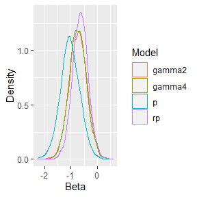

```r
sim <- data.frame(Model=rep(c("gamma2", "p", "gamma4", "rp"), each=(upper - lower + 1)), beta= c(mcmc$samples[lower:upper, dim], mcmc_c$samples[lower:upper, dim], mcmc_g4$samples[lower:upper, dim], mcmc_rc$samples[lower:upper, dim]))
ggplot(sim, aes(x=beta, color=Model)) + geom_density() + xlab("Beta") + ylab("Density")
```

Because of the influential observation patient 27, the “p” line which represents the normal error model, is quite different from the other lines. The “gamma2” line, which represents $t(4)$ error, and “gamma4” line, which represents $t(8)$, behave similarly. With patient 27 removed, the “rp” line, which uses the normal error model without patient 27, agrees with the “gamma2” and “gamma4” lines, but the tail of the “rp” line is smaller than the “gamma2” and “gamma4” lines. This implies that removing patient 27 may underestimate uncertainties.

## Monotone Example

We show a monotone missing structure situation by removing the InSC values of observations 29 and 30.

```r
ym <- creatinine_data[c("InSC", "InWT", "InCR")]
ym[29, 1] = NA
ym[30, 1] = NA

monm <- ismonotone(ym, x)
```

The data now is monotone.

```r
monm$monotone
```

```
#> [1] TRUE
```

Permute the rows and columns are required.

```r
monm$permute
```

```
#> [1] TRUE
```

```r
yobs1 <- monm$ynew
xobs1 <- monm$xnew
```

When the missing structure is monotone. Use the rearranged data for later analysis, since the data is required to be in the standard monotone format.

Shows the locations of the rows and columns in the original data.

```r
monm$ynew_column
```

```
#> [1] 1 2 3
```

```r
monm$ynew_row
```

```
#>  [1]  1  2  3  4  5  6  7  8  9 10 11 12 13 14 15 16 17 18 19 20 21 22 23 24 25
#> [26] 26 27 28 31 32 33 34 29 30
```

We should switch rows 29, 30 and 33, 34 to get the standard monotone format.

The function calls the DA algorithm, which is the most efficient one in this situation.

```r
mcmcm <- dageneral(xobs1, yobs1, m=ncol(yobs1),A=diag(0,ncol(yobs1)), cw=cw_gamma, iter=iter)
```

```
#> [1] "da"
```

The algorithm generates a Markov chain with length 5000. And the computation time is 49.07.

## Data Augmentation Algorithms Comparison

When the missing structure is monotone, both the DA and DAI algorithms can be efficiently implemented. We showed that the DAI algorithm will never be faster than the corresponding DA version. We did a numerical experiment, calculating the effective sample sizes and effective sample sizes per minute. The DA algorithm is considerably more efficient even after considering the computation complexity. See our [paper](http://arxiv.org/abs/2212.01712) Section 4.4 and Section 5 for more details.

## Efficient Problem Size

In the example above, we have $d=3$ response, $p=2$ predictors, and $n=34$ observations. The model can be implemented at a reasonable computation time at $d=20$, $p=100$, and $n=500$. The storage cost is also a burden if the question is too large.

# Appendix

## Data Augmentation Algorithms in Different Situations

Here is an example on implementing data augmentation algorithms in different situations using artificial data. Interested readers can run the code below by themselves.

```r
set.seed(1)
library(GeneralizedHyperbolic)
library(LaplacesDemon)
library(matlib)
library(MASS)
library(matrixNormal)

# generate data
library(mvtnorm)
n <- 50
X <- cbind(1, as.matrix(rnorm(n, 0, 1)))
beta <- matrix(c(0.8, 0.4, 0.5, 0.3), nrow=2, ncol=2)
var <- matrix(c(1, 0.6, 0.6, 2), 2, 2)
error <- matrix(0, nrow=n, ncol=2)
w <- rgamma(n, shape=2, rate=2)
for (i in 1:n) {
  error[i, ] <- rmvnorm(1, rep(0, nrow(var)), var / w[i])
}
yobs <- X %*% beta + error
data <- cbind(yobs, X[, 2])
data_d <- cbind(X[, 2], yobs)
colnames(data_d) <- c("x", "yr1", "yr2")

# display data
library(GGally)
ggpairs(data.frame(data_d))
# ggsave("scatter.png", width=150, height=100, dpi=700, units="mm")
rm(data_d)
```

```r
# Parameters
d <- ncol(yobs)
m <- d # prior parameter
A <- matrix(0, nrow=d, ncol=d) # matrix in the prior

iter <- 1000
lower <- 10 # burn-in
upper <- iter + 1
dim <- 2 # beta_21
```

```r
# Bayesian robust multivariate linear regression DA algorithm
## There is no missing value. In this situation, the mda_gibbs and dami_gibbs coincide.
## cw_gamma default is gamma(2, 2)
resdag <- dageneral(X, yobs, m, A, cw=cw_gamma, iter=iter) # da monotone
resdaig <- dageneral(X, yobs, m, A, cw=cw_gamma, Ik=matrix(TRUE, nrow=nrow(yobs), ncol=ncol(yobs)),  iter=iter) # daimf fully observed

# plot histogram
sim <- data.frame(Model=rep(c("dag", "daimfg"), each=(upper - lower + 1)), beta=c(resdag$samples[lower:upper, dim], resdaig$samples[lower:upper, dim]))
ggplot(sim, aes(x=beta, color=Model)) + geom_density() + xlab("Beta") + ylab("Density")
```

```r
# create monotone missing data
for (i in c(47:50)) {
  yobs[i, 1] <- NA
}

# implement
resdag <- dageneral(X, yobs, m, A, cw=cw_gamma, iter=iter) # da monotone
resdaig <- dageneral(X, yobs, m, A, cw=cw_gamma,
Ik=matrix(TRUE, nrow=nrow(yobs), ncol=ncol(yobs)),  iter=iter) # daimf monotone and impute to fully observed

# plot histogram
sim <- data.frame(Model=rep(c("dag", "daig"), each=(upper - lower + 1)), beta=c(resdag$samples[lower:upper, dim], resdaig$samples[lower:upper, dim]))
ggplot(sim, aes(x=beta, color=Model)) + geom_density() + xlab("Beta") + ylab("Density")
```

```r
# impute missing response values
resdagy <- dageneral(X, yobs, m, A, cw=cw_gamma, iter=iter, yfull=TRUE)
resdaigy <- dageneral(X, yobs, m, A, cw=cw_gamma,
Ik=matrix(TRUE, nrow=nrow(yobs), ncol=ncol(yobs)),  iter=iter, yfull=TRUE) # daimf# da
id <- ncol(resdagy$samples)
# plot histogram
sim <- data.frame(Model=rep(c("dag", "daimfg"), each=(upper - lower + 1)), beta=c(resdagy$samples[lower:upper, id], resdaigy$samples[lower:upper, id]))
ggplot(sim, aes(x=beta, color=Model)) + geom_density() + xlab("yimputed") + ylab("Density")
```

```r
# create non-monotone missing data
for (i in c(47:50)) {
  yobs[i, 1] <- NA
}

yobs[45, 2] <- NA
Ik <- !is.na(yobs)
Ik[45, 2] <- TRUE

# implement
resdaig <- dageneral(X, yobs, m, A, cw=cw_gamma, Ik=Ik, iter=iter) # dai
resdaifg <- dageneral(X, yobs, m, A, cw=cw_gamma, iter=iter) # daif

# plot histogram
sim <- data.frame(Model=rep(c("daig", "daifg"), each=(upper - lower + 1)), beta=c(resdag$samples[lower:upper, dim], resdaig$samples[lower:upper, dim]))
ggplot(sim, aes(x=beta, color=Model)) + geom_density() + xlab("Beta") + ylab("Density")
```

# References

Li, Haoxiang, Qian Qin, and Galin L. Jones. “Convergence Analysis of Data Augmentation Algorithms for Bayesian Robust Multivariate Linear Regression with Incomplete Data.” arXiv preprint arXiv:2212.01712 (2022).

Liu, Chuanhai. “Bayesian robust multivariate linear regression with incomplete data.” Journal of the American Statistical Association 91.435 (1996): 1219-1227.

Shih, Weichung J., and Sanford Weisberg. “Assessing influence in multiple linear regression with incomplete data.” Technometrics 28.3 (1986): 231-239.